# External validation of the final step-counting models on MAREA

Do our fitted models behave like the paper’s, and did we fit them the way the paper did?

```python
import json, sys
from pathlib import Path
import numpy as np, pandas as pd
import matplotlib.pyplot as plt

ROOT = Path.cwd()
while not (ROOT / "step_counting").exists():
    ROOT = ROOT.parent
sys.path.insert(0, str(ROOT))
CACHE = ROOT / "analysis" / "cache"
if not (CACHE / "marea_counts.csv").exists():
    raise SystemExit("Run `python analysis/marea_eval.py` first (computes the caches, ~15 min on CPU).")

plt.rcParams.update({"figure.dpi": 110, "axes.spines.top": False, "axes.spines.right": False,
                     "axes.grid": True, "grid.alpha": .25, "legend.frameon": False})
MODELS = ["clemson", "combined", "oxwalk"]
COL = {"clemson": "#1b6ca8", "combined": "#2a9d8f", "oxwalk": "#d1495b"}
ACTS = ["treadmill_walk", "treadmill_slopewalk", "indoor_walk", "outdoor_walk",
        "treadmill_run", "indoor_run", "outdoor_run"]
RNG = np.random.default_rng(0)

d = pd.read_csv(CACHE / "marea_counts.csv")
d["kind"] = np.where(d.activity.str.contains("run"), "run", "walk")
d["pe"] = (d.mass - d.true) / d.true * 100          # percentage error  (paper: PE)
d["ape"] = d.pe.abs()                                # absolute percentage error (paper: APE)
d["spm"] = d.true / (d.duration_s / 60)              # true steps / min
probs = np.load(CACHE / "marea_probs.npz")
dist = json.loads((CACHE / "distributions.json").read_text())

def boot(g, n=2000):
    """Paper-style metric: MAPE/MPE over evaluation units, 95% bootstrap CI resampling *participants*
    (all of a participant's recordings kept together)."""
    subs = g.subject.unique()
    by = {s: g[g.subject == s] for s in subs}
    mape, mpe = [], []
    for _ in range(n):
        b = pd.concat([by[s] for s in RNG.choice(subs, len(subs))])
        mape.append(b.ape.mean()); mpe.append(b.pe.mean())
    f = lambda a: (np.mean(a), *np.percentile(a, [2.5, 97.5]))
    return dict(MAPE=g.ape.mean(), MAPE_lo=np.percentile(mape, 2.5), MAPE_hi=np.percentile(mape, 97.5),
                MPE=g.pe.mean(), MPE_lo=np.percentile(mpe, 2.5), MPE_hi=np.percentile(mpe, 97.5),
                n=len(g), pooled_bias=(g.mass.sum() - g.true.sum()) / g.true.sum() * 100)

def table(by):
    rows = []
    for k, g in d.groupby(by):
        r = boot(g); r.update(dict(zip(by, k if isinstance(k, tuple) else (k,)))); rows.append(r)
    return pd.DataFrame(rows)

def fmt(r, m="MAPE"):
    return f"{r[m]:.1f} [{r[m+'_lo']:.1f}, {r[m+'_hi']:.1f}]"
```

# Summary

**Question.** Models fitted with `scripts/fit_final_*.py` (`clemson`, `oxwalk`, and a pooled `combined` model) were evaluated on **MAREA** (Khandelwal & Wickström), an external dataset none of them saw: wrist accelerometer at 128 Hz, with heel strikes from shoe pressure sensors as the step reference (19 participants, 68 recordings, 41,367 steps). We asked (1) whether the models behave in line with the published results (Zhang, Lago & Nguyen, *Sensors* 2026, “Temporal Step Supervision”) and (2) whether anything about *how we fit them* departs from the paper’s protocol.

```python
walk = d[d.kind == "walk"]; run = d[d.kind == "run"]
sw = {m: boot(walk[walk.model == m], 1000) for m in MODELS}
sr = {m: boot(run[run.model == m], 1000) for m in MODELS}
from IPython.display import Markdown
Markdown("\n".join([
 "| model | walking MAPE % | walking MPE % | running MAPE % | running MPE % |", "|---|---|---|---|---|"] +
 [f"| {m} | {fmt(sw[m])} | {fmt(sw[m],'MPE')} | {fmt(sr[m])} | {fmt(sr[m],'MPE')} |" for m in MODELS]) +
 "\n\n*Participant-bootstrap 95% CI in brackets. Units are participant × activity recordings (paper convention). "
 "MPE < 0 means undercounting.*")
```

| model | walking MAPE % | walking MPE % | running MAPE % | running MPE % |
| --- | --- | --- | --- | --- |
| clemson | 12.1 [8.4, 16.8] | -11.8 [-16.6, -8.0] | 26.1 [20.8, 31.6] | -26.1 [-31.6, -20.8] |
| combined | 8.4 [5.9, 11.4] | -7.9 [-11.1, -5.0] | 43.9 [36.1, 52.6] | -43.9 [-52.6, -36.1] |
| oxwalk | 13.2 [9.2, 18.4] | -0.5 [-7.2, 5.5] | 83.3 [70.3, 91.8] | -83.0 [-91.8, -69.5] |

*Participant-bootstrap 95% CI in brackets. Units are participant × activity recordings (paper convention). MPE < 0 means undercounting.*

**Findings, in short** (each is demonstrated below):

1. **Walking: in line with the paper’s cross-dataset results.** Per-recording MAPE is 8–13 % (combined 8 %, clemson 12 %, oxwalk 13 %), at or below the paper’s zero-shot range (13–29 % MAPE; Section 6). `clemson` and `combined` undercount (MPE −12 % and −8 %); `oxwalk` is unbiased on average (−0.5 %) but with ±13 % scatter per recording. This is somewhat worse than the paper’s in-domain (held-out) numbers, as expected for an unseen sensor and protocol.
2. **Against the open-source algorithms on MAREA** (Koffman et al.), our models’ walking count error is comparable to stepcount SSL/RF and better than Oak, ActiLife, ADEPT and Verisense (Section 6.2); SSL’s published speed analysis suggests it handles running better than ours do.
3. **Running: the models fail, and they were never asked to run. Training on MAREA running fixes it (held-out ~3 % MAPE, Section 9).** Neither paper dataset contains running: ~98 % of annotated training steps are below 140 steps/min, while ~79 % of MAREA running steps are above it, and running wrist amplitude is ~5–9× the walking amplitude the raster was calibrated to (Section 4). This is a domain-coverage limit, not evidence of a broken fit. A diagnostic (Section 7) gives only partial support to the cadence explanation (making running look 25 % slower halves the undercount) and **no support** for the amplitude-clipping explanation (shrinking the signal made things worse), so the cause is not fully pinned down.
4. **Our final fits reproduce the paper’s recipe in the ways that matter** (optimiser, schedule, loss, label widths, preprocessing, raster ranges), with three real differences that need to be known: no held-out split / no validation-based checkpoint selection for the OxWalk model, all participants used for training (so there is no in-fit generalisation estimate), and a documentation inconsistency in the paper’s early-stopping description (Section 8).
5. **None of these differences is large enough to explain the walking undercount or the running failure.** The one fitting-related choice with a plausible, testable effect on the *final* model is the late-training count-loss weighting (Section 2), and it is worth a held-out ablation rather than a guess.

# 1. Data and models

```python
man = pd.read_csv(ROOT / "data/marea/manifest.csv")
t = (man.groupby("activity").agg(recordings=("file", "size"), participants=("subject", "nunique"),
        hours=("duration_s", lambda s: s.sum() / 3600), steps=("n_steps", "sum"),
        median_steps_per_min=("steps_per_min", "median")).loc[ACTS].round(2))
t
```

| activity | recordings | participants | hours | steps | median_steps_per_min |
| --- | --- | --- | --- | --- | --- |
| treadmill_walk | 10 | 10 | 1.32 | 9379 | 118.05 |
| treadmill_slopewalk | 10 | 10 | 1.78 | 11632 | 109.50 |
| indoor_walk | 10 | 10 | 0.50 | 3371 | 111.90 |
| outdoor_walk | 9 | 9 | 0.51 | 3729 | 121.80 |
| treadmill_run | 10 | 10 | 0.52 | 4663 | 149.95 |
| indoor_run | 10 | 10 | 0.51 | 4677 | 149.60 |
| outdoor_run | 9 | 9 | 0.40 | 3916 | 165.80 |

|  | `clemson` | `combined` | `oxwalk` |
| --- | --- | --- | --- |
| training data | Clemson wrist (30 people) | Clemson + OxWalk wrist, 15 Hz (69 people) | OxWalk wrist (39 people) |
| model rate / window | 15 Hz / 60 s (T=900) | 15 Hz / 60 s | 25 Hz / 60 s (T=1500) |
| input | gravity-removed raster | gravity-removed raster | unprocessed raster |
| label width | 5 | 5 | 7 |
| in the paper? | yes (Clemson main model) | **no** (our addition) | yes (OxWalk main model) |

Inputs at inference are put on the model’s footing by `step_counting/inference.py`: polyphase resampling to the model rate, the model’s own preprocessing, the saved training raster ranges, 60 s windows, and mass counting `Σp / label_width`. MAREA’s wrist is 128 Hz in g, so every model sees a resampled signal (128 → 15 or 25 Hz).

**Step definition.** MAREA gives heel strikes (left + right, one step each) from foot pressure sensors. Clemson and OxWalk use video-annotated steps. These should agree on counts, but not on exact timing (Section 6).

# 2. Fit health: training loss

The training logs only have the *total* loss, so the curves below are the hybrid loss $(1-\alpha)\,\text{BCE} + \alpha\,\text{count-MSE}$ together with the count weight $\alpha$.

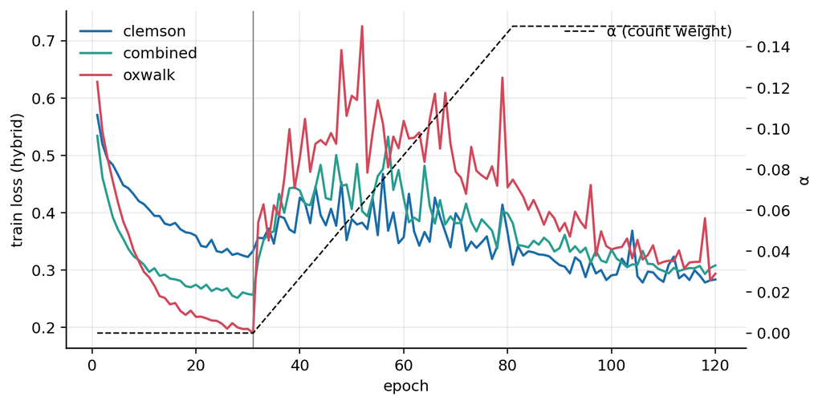

Figure 1: Training loss of the three final fits. The jump at epoch 32 coincides with the count term switching on (α>0), not with overfitting.

```python
fig, ax = plt.subplots(1, 1, figsize=(8, 4))
for m in MODELS:
    ll = pd.read_csv(ROOT / f"runs/final_{m}/loss_log.csv")
    ax.plot(ll.epoch, ll.train_loss, color=COL[m], label=m)
ep = np.arange(1, 121)
alpha = np.clip((ep - 1 - 30) / 50, 0, 1) * 0.15
ax2 = ax.twinx(); ax2.plot(ep, alpha, "k--", lw=1, label="α (count weight)"); ax2.set_ylabel("α"); ax2.grid(False)
ax.axvline(31, color="gray", lw=.8); ax.set_xlabel("epoch"); ax.set_ylabel("train loss (hybrid)")
ax.legend(loc="upper left"); ax2.legend(loc="upper right")
plt.show()
```

# 3. Do the predictions agree with the reference?

## 3.1 Counts

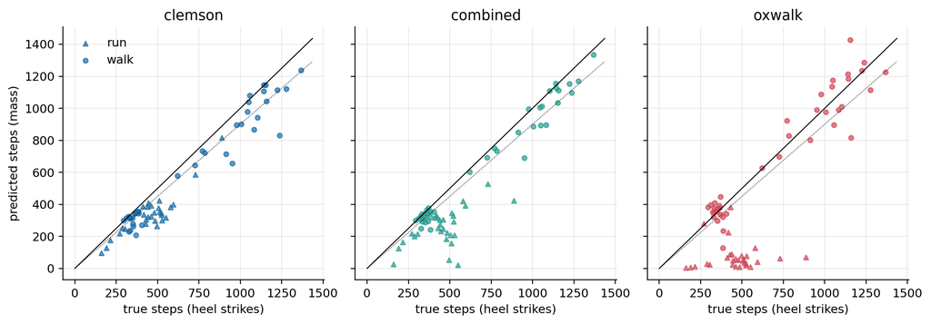

Figure 2: Predicted vs true steps per recording. Walking sits close to the identity line, slightly below it; running falls far below, worst for oxwalk.

```python
fig, axs = plt.subplots(1, 3, figsize=(11, 3.9), sharex=True, sharey=True)
mk = {"walk": "o", "run": "^"}
for ax, m in zip(axs, MODELS):
    g = d[d.model == m]
    for k, gg in g.groupby("kind"):
        ax.scatter(gg.true, gg.mass, s=16, marker=mk[k], color=COL[m], alpha=.7, label=k)
    lim = [0, d.true.max() * 1.05]; ax.plot(lim, lim, "k-", lw=.8); ax.plot(lim, [x * .9 for x in lim], "k:", lw=.6)
    ax.set_title(m); ax.set_xlabel("true steps (heel strikes)")
axs[0].set_ylabel("predicted steps (mass)"); axs[0].legend(); plt.tight_layout(); plt.show()
```

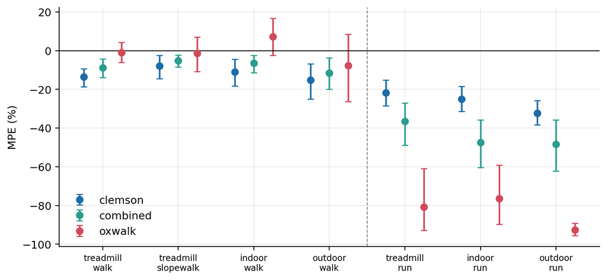

Figure 3: Mean percentage error (MPE) by activity with participant-bootstrap 95% CI. Negative = undercount.

```python
tb = table(["model", "activity"])
fig, ax = plt.subplots(figsize=(9, 4))
for i, m in enumerate(MODELS):
    r = tb[tb.model == m].set_index("activity").loc[ACTS]
    x = np.arange(len(ACTS)) + (i - 1) * .25
    ax.errorbar(x, r.MPE, yerr=[r.MPE - r.MPE_lo, r.MPE_hi - r.MPE], fmt="o", color=COL[m], label=m, capsize=3)
ax.axhline(0, color="k", lw=.8); ax.axvline(3.5, color="gray", ls="--", lw=.8)
ax.set_xticks(range(len(ACTS))); ax.set_xticklabels([a.replace("_", "\n") for a in ACTS], fontsize=8)
ax.set_ylabel("MPE (%)"); ax.legend(); plt.show()
```

```python
out = tb.assign(MAPE_ci=tb.apply(fmt, axis=1), MPE_ci=tb.apply(lambda r: fmt(r, "MPE"), axis=1))
out = out.pivot(index="activity", columns="model", values=["MAPE_ci", "MPE_ci"]).loc[ACTS]
out
```

Table 1

| model activity | MAPE_ci clemson | MAPE_ci combined | MAPE_ci oxwalk | MPE_ci clemson | MPE_ci combined | MPE_ci oxwalk |
| --- | --- | --- | --- | --- | --- | --- |
| treadmill_walk | 13.6 [9.3, 18.6] | 9.1 [5.0, 14.0] | 7.1 [4.6, 9.6] | -13.6 [-18.6, -9.3] | -8.7 [-13.8, -4.3] | -1.0 [-6.0, 4.3] |
| treadmill_slopewalk | 8.4 [3.4, 14.7] | 5.6 [2.9, 8.5] | 11.4 [6.4, 17.1] | -7.8 [-14.4, -2.4] | -5.2 [-8.4, -2.2] | -1.3 [-10.9, 7.1] |
| indoor_walk | 11.6 [5.5, 18.6] | 6.8 [3.0, 11.6] | 13.9 [7.8, 20.1] | -11.0 [-18.3, -4.4] | -6.4 [-11.3, -2.4] | 7.3 [-2.3, 16.7] |
| outdoor_walk | 15.1 [6.8, 25.0] | 12.5 [5.4, 20.4] | 21.2 [10.8, 35.1] | -15.1 [-25.0, -6.8] | -11.5 [-20.0, -3.7] | -7.7 [-26.3, 8.6] |
| treadmill_run | 21.7 [15.2, 28.5] | 36.4 [27.0, 48.9] | 81.7 [63.4, 92.8] | -21.7 [-28.5, -15.2] | -36.4 [-48.9, -27.0] | -80.9 [-92.8, -61.0] |
| indoor_run | 25.0 [18.4, 31.5] | 47.5 [35.9, 60.3] | 76.4 [59.1, 89.8] | -25.0 [-31.5, -18.4] | -47.5 [-60.3, -35.9] | -76.4 [-89.8, -59.1] |
| outdoor_run | 32.2 [25.8, 38.4] | 48.3 [35.8, 62.2] | 92.6 [89.2, 95.6] | -32.2 [-38.4, -25.8] | -48.3 [-62.2, -35.8] | -92.6 [-95.6, -89.2] |

- **Walking** (four rows): per-recording MAPE is 8.4 % (`combined`), 12.1 % (`clemson`) and 13.2 % (`oxwalk`); mean error is −7.9 %, −11.8 % and −0.5 %. `oxwalk` is nearly unbiased overall only because over- and under-counts cancel (its MAPE is still 13 %); `clemson` is the most consistently low. `combined` has the lowest walking error, but the intervals overlap, so the ordering is suggestive only.
- **Running** (three rows): large undercounts for all (MPE −26 % `clemson`, −44 % `combined`, −83 % `oxwalk`). The model that trained on the most data is not the best here.

## 3.2 Does the error depend on cadence?

```python
fig, axs = plt.subplots(1, 3, figsize=(11, 3.7), sharey=True)
for ax, m in zip(axs, MODELS):
    g = d[d.model == m]
    for k, gg in g.groupby("kind"):
        ax.scatter(gg.spm, gg.pe, s=16, marker=mk[k], color=COL[m], alpha=.7)
    ax.axhline(0, color="k", lw=.8); ax.axvline(140, color="gray", ls=":", lw=.8)
    ax.set_title(m); ax.set_xlabel("true steps / min")
axs[0].set_ylabel("percentage error (%)"); plt.tight_layout(); plt.show()
cc = d.groupby("model").apply(lambda g: pd.Series({"r (cadence, PE)": np.corrcoef(g.spm, g.pe)[0, 1],
        "r (walk only)": np.corrcoef(g[g.kind=='walk'].spm, g[g.kind=='walk'].pe)[0, 1]})).round(2); cc
```

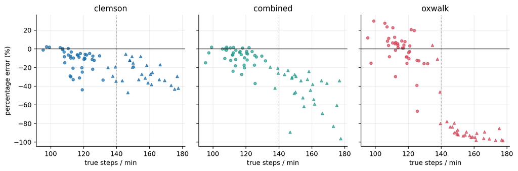

(a) Percentage error vs true cadence (steps/min). Error is near zero below ~110 steps/min (few recordings), drifts negative from ~120, and is strongly negative above ~130–140; running recordings (triangles) are the high-cadence tail.

| model | r (cadence, PE) | r (walk only) |
| --- | --- | --- |
| clemson | -0.63 | -0.40 |
| combined | -0.82 | -0.28 |
| oxwalk | -0.91 | -0.49 |

(b)

Figure 4

# 4. Why: how MAREA differs from the training data

## 4.1 Cadence

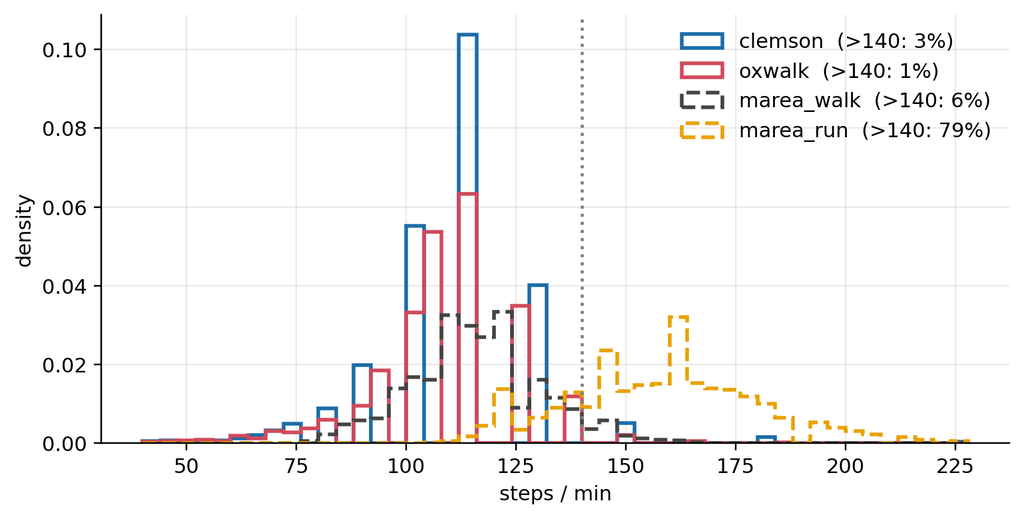

```python
fig, ax = plt.subplots(figsize=(8, 3.8))
bins = np.arange(40, 230, 4)
for k, c, ls in [("clemson", "#1b6ca8", "-"), ("oxwalk", "#d1495b", "-"), ("marea_walk", "#444", "--"), ("marea_run", "#e9a100", "--")]:
    v = np.asarray(dist["cadence"][k]); ax.hist(v, bins, density=True, histtype="step", lw=1.8, color=c, ls=ls,
                                               label=f"{k}  (>{140}: {np.mean(v > 140)*100:.0f}%)")
ax.axvline(140, color="gray", ls=":"); ax.set_xlabel("steps / min"); ax.set_ylabel("density"); ax.legend(); plt.show()
```

## 4.2 Signal amplitude and the raster range

The raster input clips each axis to a **fixed training range** (`bin_ranges.csv`, the 0.5/99.5 percentiles of the training signal) before quantising to 16 bins. Anything outside is clipped flat.

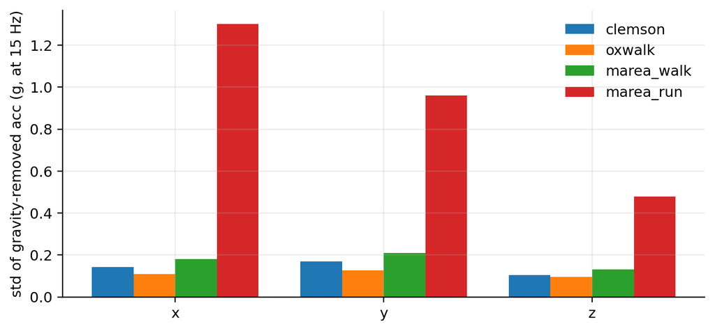

(a) Gravity-removed amplitude: standard deviation per axis. MAREA walking is ~1.3× Clemson; MAREA running is ~5–9×. The raster range the clemson/combined models use is only about ±0.5 g.

|  | model range (vmin..vmax, g) | MAREA-run 0.5–99.5 pct (gravity-removed) |
| --- | --- | --- |
| clemson | [-0.49, 0.50] \| [-0.50, 0.64] \| [-0.35, 0.37] | [-3.1, 3.0] \| [-2.5, 2.3] \| [-1.4, 1.4] |
| combined | [-0.46, 0.45] \| [-0.50, 0.56] \| [-0.36, 0.37] | [-3.1, 3.0] \| [-2.5, 2.3] \| [-1.4, 1.4] |
| oxwalk | [-1.27, 1.06] \| [-1.53, 1.20] \| [-0.94, 1.07] | NaN |

(b)

Figure 6

```python
ax_names = ["x", "y", "z"]
fig, ax = plt.subplots(figsize=(8, 3.6))
w = .2
for i, k in enumerate(["clemson", "oxwalk", "marea_walk", "marea_run"]):
    ax.bar(np.arange(3) + (i - 1.5) * w, dist["axes"][k]["grav_removed_std"], w, label=k)
ax.set_xticks(range(3)); ax.set_xticklabels(ax_names); ax.set_ylabel("std of gravity-removed acc (g, at 15 Hz)"); ax.legend(); plt.show()
br = {m: pd.read_csv(ROOT / f"runs/final_{m}/bin_ranges.csv") for m in MODELS}
pd.DataFrame({"model range (vmin..vmax, g)": {m: " | ".join(f"[{r.vmin:.2f}, {r.vmax:.2f}]" for r in br[m].itertuples()) for m in MODELS},
              "MAREA-run 0.5–99.5 pct (gravity-removed)": {m: " | ".join(f"[{a:.1f}, {b:.1f}]" for a, b in zip(dist['axes']['marea_run']['grav_removed_p005'], dist['axes']['marea_run']['grav_removed_p995'])) for m in ["clemson", "combined"]}})
```

For `clemson`/`combined` (gravity removed, range about ±0.5 g) a running signal of ±3 g lies far outside the raster range, so one would expect clipping on most strides. `oxwalk` uses unprocessed acceleration with a wider range (about ±1.3 g), but running (±4 g raw) is also outside it. This is a **hypothesis**: Section 7 tests it directly and it is *not* supported.

## 4.3 Orientation (affects `oxwalk` most)

```python
pd.DataFrame({k: dict(zip(["mean x", "mean y", "mean z"], np.round(v["raw_mean"], 2))) | dict(zip(["std x", "std y", "std z"], np.round(v["raw_std"], 2)))
              for k, v in dist["axes"].items()}).T
```

|  | mean x | mean y | mean z | std x | std y | std z |
| --- | --- | --- | --- | --- | --- | --- |
| clemson | -0.31 | 0.56 | 0.05 | 0.50 | 0.59 | 0.38 |
| oxwalk | -0.29 | -0.12 | 0.30 | 0.57 | 0.59 | 0.45 |
| marea_walk | 0.06 | -0.31 | 0.12 | 0.40 | 1.06 | 0.27 |
| marea_run | 0.44 | 0.01 | 0.07 | 1.68 | 1.19 | 0.64 |

The mean of the *raw* signal is the gravity direction. It differs between datasets (the gravity- bearing axis is *y* in Clemson, mixed in OxWalk, and *y* with a large spread in MAREA walking), so the wrist/sensor axes are **not** harmonised across cohorts. `clemson`/`combined` are protected because gravity is subtracted before rasterisation; `oxwalk` takes the raw signal and so inherits any orientation difference. MAREA walking works acceptably for `oxwalk` anyway, so orientation is a risk to monitor rather than a demonstrated cause here.

# 5. Where in time do the models place steps?

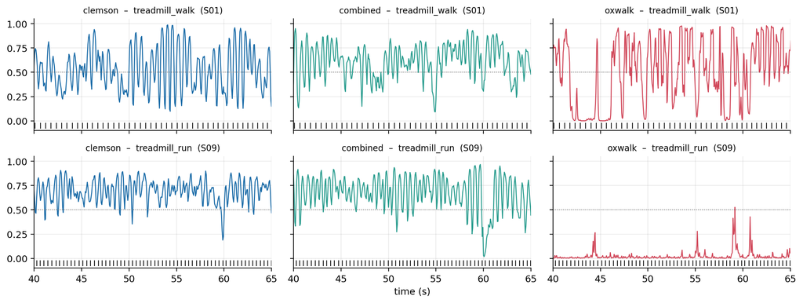

```python
ev = pd.read_csv(ROOT / "data/marea/events.csv")
def pick(act, m="combined"):
    g = d[(d.model == m) & (d.activity == act)]
    return int(g.iloc[(g.pe - g.pe.median()).abs().argmin()].subject)
fig, axs = plt.subplots(2, 3, figsize=(12, 4.6), sharex=True, sharey=True)
for i, act in enumerate(["treadmill_walk", "treadmill_run"]):
    s = pick(act)
    et = ev[(ev.activity == act) & (ev.subject == s)].time_s.to_numpy()
    for j, m in enumerate(MODELS):
        p = probs[f"{m}|{act}|{s}"]; fs = int(d[d.model == m].model_fs.iloc[0]); t = np.arange(len(p)) / fs
        a = axs[i, j]; a.plot(t, p, color=COL[m], lw=1)
        a.vlines(et, -.08, -.02, color="k", lw=.8); a.axhline(.5, color="gray", ls=":", lw=.8)
        a.set_xlim(40, 65); a.set_ylim(-.1, 1.05); a.set_title(f"{m}  –  {act}  (S{s:02d})", fontsize=9)
axs[1, 1].set_xlabel("time (s)"); plt.tight_layout(); plt.show()
```

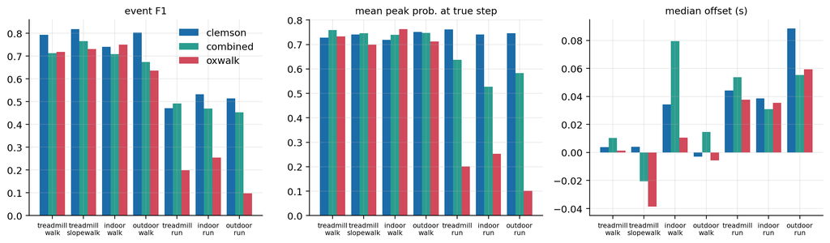

(a) Event-level agreement with heel strikes (±0.25 s tolerance), and mean peak probability at true steps.

| model | kind | prec | rec | f1 | peak_prob | median_offset_s |
| --- | --- | --- | --- | --- | --- | --- |
| clemson | run | 0.994 | 0.364 | 0.505 | 0.750 | 0.056 |
|  | walk | 0.894 | 0.715 | 0.789 | 0.735 | 0.010 |
| combined | run | 0.987 | 0.320 | 0.472 | 0.583 | 0.046 |
|  | walk | 0.903 | 0.605 | 0.716 | 0.748 | 0.021 |
| oxwalk | run | 0.952 | 0.116 | 0.187 | 0.188 | 0.044 |
|  | walk | 0.883 | 0.610 | 0.711 | 0.728 | -0.008 |

(b)

Figure 8

```python
d["prec"] = d.tp / (d.tp + d.fp).clip(lower=1); d["rec"] = d.tp / (d.tp + d.fn).clip(lower=1)
d["f1"] = 2 * d.prec * d.rec / (d.prec + d.rec).clip(lower=1e-9)
fig, axs = plt.subplots(1, 3, figsize=(12, 3.6))
for ax, (col, lab) in zip(axs, [("f1", "event F1"), ("peak_prob", "mean peak prob. at true step"), ("median_offset_s", "median offset (s)")]):
    for i, m in enumerate(MODELS):
        r = d[d.model == m].groupby("activity")[col].mean().loc[ACTS]
        ax.bar(np.arange(len(ACTS)) + (i - 1) * .27, r, .27, color=COL[m], label=m)
    ax.set_xticks(range(len(ACTS))); ax.set_xticklabels([a.replace("_", "\n") for a in ACTS], fontsize=7); ax.set_title(lab, fontsize=10)
axs[0].legend(); plt.tight_layout(); plt.show()
d.groupby(["model", "kind"])[["prec", "rec", "f1", "peak_prob", "median_offset_s"]].mean().round(3)
```

# 6. Comparison with published results

The paper reports **held-out** results on its own datasets, and zero-shot transfer between them. MAREA is a third dataset, so the fair comparison for our walking results is the paper’s *zero-shot* tables, not its in-domain tables. The paper has no running data.

```python
paper = pd.DataFrame([
 ["In-domain, held-out", "Clemson wrist, regular",      4.61,  -2.33],
 ["In-domain, held-out", "Clemson wrist, semi-regular",  9.90,  -5.28],
 ["In-domain, held-out", "Clemson wrist, irregular",    15.78,   2.87],
 ["In-domain, held-out", "OxWalk wrist (free-living)",  13.06,  -2.78],
 ["Zero-shot OxWalk→Clemson", "regular",               12.97,  -7.84],
 ["Zero-shot OxWalk→Clemson", "semi-regular",          13.04,  -8.68],
 ["Zero-shot OxWalk→Clemson", "irregular",             16.56,  -1.11],
 ["Zero-shot Clemson→OxWalk", "OxWalk (participants)", 28.75,  10.89],
], columns=["setting", "data", "paper MAPE %", "paper MPE %"])
mw = pd.DataFrame({m: dict(zip(["ours MAPE %", "ours MPE %"], [round(sw[m]["MAPE"], 1), round(sw[m]["MPE"], 1)])) for m in MODELS}).T
display(paper)
print("Ours on MAREA walking (all four walking activities pooled):")
mw
```

```
Ours on MAREA walking (all four walking activities pooled):
```

Table 2

|  | setting | data | paper MAPE % | paper MPE % |
| --- | --- | --- | --- | --- |
| 0 | In-domain, held-out | Clemson wrist, regular | 4.61 | -2.33 |
| 1 | In-domain, held-out | Clemson wrist, semi-regular | 9.90 | -5.28 |
| 2 | In-domain, held-out | Clemson wrist, irregular | 15.78 | 2.87 |
| 3 | In-domain, held-out | OxWalk wrist (free-living) | 13.06 | -2.78 |
| 4 | Zero-shot OxWalk→Clemson | regular | 12.97 | -7.84 |
| 5 | Zero-shot OxWalk→Clemson | semi-regular | 13.04 | -8.68 |
| 6 | Zero-shot OxWalk→Clemson | irregular | 16.56 | -1.11 |
| 7 | Zero-shot Clemson→OxWalk | OxWalk (participants) | 28.75 | 10.89 |

|  | ours MAPE % | ours MPE % |
| --- | --- | --- |
| clemson | 12.1 | -11.8 |
| combined | 8.4 | -7.9 |
| oxwalk | 13.2 | -0.5 |

**Reading.** Our MAREA walking per-recording MAPE (8–13 %; MPE −8 % `combined`, −12 % `clemson`, −0.5 % `oxwalk`) is at or below the paper’s zero-shot range (≈13–29 % MAPE; MPE −8 to +11 %) and is better than the paper’s worst cases, partly because MAREA walking is mostly steady treadmill/indoor walking (closest to Clemson “regular”, the easiest condition) rather than free-living. The sign of the bias for `clemson`/`combined` (undercount) matches the paper’s OxWalk→Clemson direction, not its Clemson→OxWalk direction (overcount); `oxwalk` shows no net bias. Qualitatively the story agrees: the model transfers reasonably to unseen steady walking and degrades when the behaviour leaves the training distribution.

**What cannot be concluded.** MAREA walking is not the paper’s hard case (irregular / free-living walking), so this validation says little about the paper’s headline claim of robustness under irregular gait. It supports “no gross problem with the fit on steady walking”; it does not test the claim.

## 6.1 Resubstitution check (does our fit reproduce sensible in-sample counts?)

The final models were trained on *all* participants, so the following is **not** a held-out test and must not be compared to the paper’s 10.1 % / 13.1 % as if it were. It only checks the fit is not broken: a healthy fit should be at or below the paper’s held-out error.

```python
f1, f2 = CACHE / "insample_clemson.csv", CACHE / "insample_oxwalk.csv"
if f1.exists() and f2.exists():
    c = pd.read_csv(f1); c["ape"] = (c.mass - c.true).abs() / c.true * 100; c["pe"] = (c.mass - c.true) / c.true * 100
    o = pd.read_csv(f2); o["ape"] = (o.mass - o.true).abs() / o.true * 100; o["pe"] = (o.mass - o.true) / o.true * 100
    pc = c.groupby("condition")[["ape", "pe"]].mean().loc[["Regular", "SemiRegular", "Irregular"]]
    pc.loc["Overall"] = c[["ape", "pe"]].mean()
    pc["paper MAPE (held-out)"] = [4.61, 9.90, 15.78, 10.10]; pc["paper MPE (held-out)"] = [-2.33, -5.28, 2.87, -1.58]
    display(pc.round(2).rename(columns={"ape": "ours MAPE (in-sample)", "pe": "ours MPE (in-sample)"}))
    print(f"OxWalk, oxwalk model in-sample: MAPE {o.ape.mean():.2f}%  MPE {o.pe.mean():.2f}%   (paper held-out: 13.06 / -2.78)")
    print("In-sample error is far below held-out error (about 1-2% vs 10-13%): the models fit their training participants tightly,")
    print("so the generalisation gap (1-2% -> 8-13% on MAREA walking) is the quantity that matters.")
else:
    print("in-sample caches not computed yet")
```

```
OxWalk, oxwalk model in-sample: MAPE 2.00%  MPE -0.99%   (paper held-out: 13.06 / -2.78)
In-sample error is far below held-out error (about 1-2% vs 10-13%): the models fit their training participants tightly,
so the generalisation gap (1-2% -> 8-13% on MAREA walking) is the quantity that matters.
```

Table 3

| condition | ours MAPE (in-sample) | ours MPE (in-sample) | paper MAPE (held-out) | paper MPE (held-out) |
| --- | --- | --- | --- | --- |
| Regular | 0.70 | 0.50 | 4.61 | -2.33 |
| SemiRegular | 0.88 | 0.01 | 9.90 | -5.28 |
| Irregular | 2.15 | -1.72 | 15.78 | 2.87 |
| Overall | 1.24 | -0.40 | 10.10 | -1.58 |

## 6.2 Versus the open-source algorithms on MAREA (Koffman et al.)

Koffman, Crainiceanu & Muschelli (“Evaluating Step Counting Algorithms on Sub-Second Wrist-Worn Accelerometry”, `pubs/Walking_algorithms_comparison.pdf`) ran ActiLife, ADEPT, Oak, SDT, Verisense and **stepcount (RF and SSL)** on the same MAREA wrist data (19 participants, 128 Hz, left wrist, heel strikes from shoe force sensors) plus Clemson and OxWalk. We can put our three models next to their MAREA numbers (their Tables 3, 4, 6; “MAREA regular”).

**How their metric is defined (checked in their code, `lilykoff/step_algorithms`).** `step_01_download_process_data.R` writes `data/processed/marea.csv.gz`, which is the same file we split (same columns; accelerometer already converted from m/s² to g). `generate_results_dfs*.R` then drops every recording whose activity name contains “run” (`filter(grepl("run", cat_activity)==FALSE)`), **sums steps across a participant’s remaining walking recordings**, computes $\text{APE}_i=|\hat C_i-C_i|/C_i\cdot100$ and bias $=\hat C_i-C_i$ per participant, and reports the mean over the 19 participants. Their Table 4 “MAREA” row is exactly this. We use the same four walking activities, the same per-participant sum, and the same APE/bias. Differences that remain: (i) they run the algorithms at 30 Hz resampled from 128 Hz (and run each algorithm on the combined walk+run file before dropping the running seconds), whereas our models run at 15/25 Hz on the walking recordings only; (ii) our step totals differ from theirs by 0–2 steps in 24 of 39 recordings (28,111 vs 28,079 steps, 0.1 %), presumably boundary handling; (iii) second-level walking recognition is as they define it (≥1 step in the second). They resample to 30 Hz before running stepcount; our models run at their native 15/25 Hz (`StepCounter` resamples from 128 Hz). Precision is not meaningful for MAREA in their analysis, so only recall and F1 are comparable and F1 there is dominated by recall.

```python
# --- our models, in the paper's convention (walking only, per participant) ---
walk_d = d[d.kind == "walk"]
def per_participant(m):
    g = walk_d[walk_d.model == m].groupby("subject")[["true", "mass", "switch"]].sum()
    ape = (g.mass - g.true).abs() / g.true * 100; bias = g.mass - g.true
    return ape, bias

def second_level(m):
    """Per-participant recall / precision / F1 of 'walking seconds' (>=1 step), from cached probabilities.
    Predicted steps = centres of runs of p>=0.5 (same hard-switch rule as the evaluation scripts)."""
    fs = int(d[d.model == m].model_fs.iloc[0]); out = {}
    for r in man[~man.activity.str.contains("run")].itertuples():
        p = probs[f"{m}|{r.activity}|{r.subject}"]; row = p >= .5
        pad = np.concatenate([[False], row, [False]])
        st = np.flatnonzero(~pad[:-1] & pad[1:]); en = np.flatnonzero(pad[:-1] & ~pad[1:])
        pred_s = ((st + en - 1) / 2 / fs).astype(int)
        true_s = np.floor(ev[(ev.subject == r.subject) & (ev.activity == r.activity)].time_s.to_numpy()).astype(int)
        n_sec = int(np.ceil(len(p) / fs)); T = np.zeros(n_sec, bool); P = np.zeros(n_sec, bool)
        T[true_s[true_s < n_sec]] = True; P[pred_s[pred_s < n_sec]] = True
        a = out.setdefault(r.subject, np.zeros(3)); a += [(T & P).sum(), (~T & P).sum(), (T & ~P).sum()]
    rec, prec, f1 = [], [], []
    for tp, fp, fn in out.values():
        R = tp / max(tp + fn, 1); Pp = tp / max(tp + fp, 1)
        rec.append(R); prec.append(Pp); f1.append(2 * R * Pp / max(R + Pp, 1e-9))
    return np.mean(rec), np.mean(prec), np.mean(f1)

rows = []
pub = {  # Koffman et al., MAREA regular: MAPE (SD), bias steps (SD), recall, F1
 "stepcount SSL (published)": (11.4, 10, -210, 262, .99, .99), "stepcount RF (published)": (12.9, 10, -232, 277, .98, .99),
 "SDT (published)": (16.1, 11, -257, 273, .99, .99), "Verisense revised (published)": (19.2, 11, -333, 324, .94, .97),
 "Verisense original (published)": (30.6, 15, -491, 445, .86, .92), "ADEPT (published)": (36.2, 23, -652, 614, .64, .75),
 "ActiLife (published)": (39.0, 13, -633, 514, .92, .96), "Oak (published)": (42.5, 28, -742, 730, .58, .69)}
for k, v in pub.items():
    rows.append(dict(method=k, MAPE=f"{v[0]:.1f} ({v[1]:.0f})", bias_steps=f"{v[2]:.0f} ({v[3]:.0f})", recall=v[4], F1=v[5]))
for m in MODELS:
    ape, bias = per_participant(m); R, P_, F = second_level(m)
    rows.append(dict(method=f"{m} (this repo, final fit)", MAPE=f"{ape.mean():.1f} ({ape.std():.0f})",
                     bias_steps=f"{bias.mean():.0f} ({bias.std():.0f})", recall=round(R, 2), F1=round(F, 2)))
kt = pd.DataFrame(rows).set_index("method")
kt
```

Table 4

| method | MAPE | bias_steps | recall | F1 |
| --- | --- | --- | --- | --- |
| stepcount SSL (published) | 11.4 (10) | -210 (262) | 0.99 | 0.99 |
| stepcount RF (published) | 12.9 (10) | -232 (277) | 0.98 | 0.99 |
| SDT (published) | 16.1 (11) | -257 (273) | 0.99 | 0.99 |
| Verisense revised (published) | 19.2 (11) | -333 (324) | 0.94 | 0.97 |
| Verisense original (published) | 30.6 (15) | -491 (445) | 0.86 | 0.92 |
| ADEPT (published) | 36.2 (23) | -652 (614) | 0.64 | 0.75 |
| ActiLife (published) | 39.0 (13) | -633 (514) | 0.92 | 0.96 |
| Oak (published) | 42.5 (28) | -742 (730) | 0.58 | 0.69 |
| clemson (this repo, final fit) | 12.7 (11) | -166 (181) | 0.91 | 0.95 |
| combined (this repo, final fit) | 9.5 (9) | -110 (119) | 0.83 | 0.91 |
| oxwalk (this repo, final fit) | 14.1 (16) | -15 (188) | 0.84 | 0.91 |

```python
kc = CACHE / "koffman_marea_totals.csv"
if not kc.exists():
    print("run: Rscript analysis/fetch_koffman_marea.R   (downloads their per-participant totals)")
else:
    from scipy import stats
    k = pd.read_csv(kc).rename(columns={"cat_activity": "activity"}); k["subject"] = k.id_subject.str[1:].astype(int)
    wide = k.pivot_table(index=["subject", "activity"], columns="algorithm", values="total_steps").reset_index()
    pp = wide.groupby("subject").sum(numeric_only=True)
    ssl = (pp.steps_scssl_30 - pp.steps_truth).abs() / pp.steps_truth * 100
    print(f"Published SSL MAPE recomputed from their totals: {ssl.mean():.1f}% (paper Table 4: 11.4%)")
    rows = []
    for m in MODELS:
        g = walk_d[walk_d.model == m].groupby("subject")[["true", "mass"]].sum()
        ape = (g.mass - g.true).abs() / g.true * 100; dlt = ape - ssl.loc[ape.index]
        se = dlt.std() / np.sqrt(len(dlt))
        rows.append(dict(model=m, MAPE=round(ape.mean(), 1), SSL_MAPE=round(ssl.mean(), 1),
                         diff_pp=round(dlt.mean(), 1), CI=f"[{dlt.mean()-2.1*se:+.1f}, {dlt.mean()+2.1*se:+.1f}]",
                         paired_t_p=round(stats.ttest_1samp(dlt, 0).pvalue, 2),
                         wilcoxon_p=round(stats.wilcoxon(dlt).pvalue, 2), better_than_SSL=f"{(dlt<0).sum()}/{len(dlt)}"))
    display(pd.DataFrame(rows).set_index("model"))
    # per activity (participant x activity), published SSL vs ours: mean percentage error
    rec = wide[["subject", "activity", "steps_truth", "steps_scssl_30"]].copy()
    rec["SSL (published)"] = (rec.steps_scssl_30 - rec.steps_truth) / rec.steps_truth * 100
    o = walk_d.assign(pe=lambda x: (x.mass - x.true) / x.true * 100).pivot_table(index=["subject", "activity"], columns="model", values="pe").reset_index()
    j = rec.merge(o, on=["subject", "activity"])
    print("Mean percentage error (MPE, %) by activity; negative = undercount")
    display(j.groupby("activity")[["SSL (published)"] + MODELS].mean().round(1))
```

```
Published SSL MAPE recomputed from their totals: 11.4% (paper Table 4: 11.4%)
```

```
Mean percentage error (MPE, %) by activity; negative = undercount
```

Table 5: Exact per-participant comparison using the totals published in the authors’ repository (30 Hz algorithms; walking only).

| model | MAPE | SSL_MAPE | diff_pp | CI | paired_t_p | wilcoxon_p | better_than_SSL |
| --- | --- | --- | --- | --- | --- | --- | --- |
| clemson | 12.7 | 11.4 | 1.3 | [-4.4, +7.1] | 0.64 | 0.18 | 5/19 |
| combined | 9.5 | 11.4 | -1.9 | [-8.0, +4.2] | 0.53 | 0.65 | 9/19 |
| oxwalk | 14.1 | 11.4 | 2.7 | [-7.5, +13.0] | 0.58 | 0.54 | 8/19 |

| activity | SSL (published) | clemson | combined | oxwalk |
| --- | --- | --- | --- | --- |
| indoor_walk | -18.5 | -11.0 | -6.4 | 7.3 |
| outdoor_walk | -6.9 | -15.1 | -11.5 | -7.7 |
| treadmill_slopewalk | -13.4 | -7.8 | -5.2 | -1.3 |
| treadmill_walk | -16.9 | -13.6 | -8.7 | -1.0 |

**Reading, with the caveats that matter.**

- **Counts are statistically indistinguishable from stepcount SSL.** Per-participant MAPE is 9.5 % (`combined`), 12.7 % (`clemson`), 14.1 % (`oxwalk`) vs 11.4 % for SSL, and mean bias −110, −166 and −15 steps vs −210. Paired by participant, the differences from SSL are −1.9, +1.3 and +2.7 percentage points with 95 % intervals spanning zero (paired t-test p 0.53–0.64; Wilcoxon p 0.18–0.65; ours better in 9, 5 and 8 of 19 participants). All three are clearly better than Oak, ActiLife, ADEPT and both Verisense versions (19–43 %). By activity SSL undercounts treadmill and indoor walking more than our models (MPE −17 % and −19 % vs −14 % to +7 %) and does better outdoors (−7 % vs −8 % to −15 %).
- **Stepcount SSL was not run by us here.** Its numbers are from the paper, produced by the paper’s authors with their own pipeline (30 Hz resampling). We did not re-run it on our `data/marea` files, so any claim of equivalence rests on the published tables only.
- **Walking recognition: stepcount SSL is clearly better.** Published recall/F1 on MAREA is 0.99/0.99 for SSL (0.98/0.99 RF, 0.99/0.99 SDT). Ours (second-level recall of walking seconds, hard threshold p ≥ 0.5) is 0.91/0.95 for `clemson` and 0.83–0.84/0.91 for `combined` and `oxwalk`, closer to ActiLife (0.92/0.96) and Verisense revised (0.94/0.97). So although our *mass* counts match SSL’s count accuracy, our models miss more walking seconds than SSL does.
- **Different target.** Stepcount SSL is a *walking-bout detector plus step counter* pretrained on a very large unlabelled corpus (UK Biobank) and fine-tuned on OxWalk, built for free-living days. Our models are dense step localisers trained from scratch on two small step-annotated datasets. On steady MAREA walking they are comparable; the paper’s free-living and irregular settings, where SSL is strongest, are exactly where MAREA does not test.
- **Running.** The Koffman paper reports that ADEPT, Oak, stepcount RF and Verisense original lose steps as speed rises into running, while the other methods (stepcount SSL among them) show no clear relationship between error and speed. Our three models belong in the first group: they lose a large and increasing share of steps in running (Section 3), which our diagnostics attribute to training-set cadence and amplitude coverage (Sections 4 and 7). So on running, the published SSL model appears to be better than ours; that comparison is qualitative (their speed plot, not re-computed here).
- **Sampling rate.** Their Table 7 shows stepcount SSL is unstable at 15 Hz (correlation with its 30 Hz output 0.08 on Clemson) but stable at ≥25 Hz (MAREA: 1.00). Our models are built for 15 Hz (clemson/combined) and 25 Hz (oxwalk), so rate sensitivity is a point in our favour for low-rate wrist data, though we have not measured it directly.

# 7. Diagnostic: is running failure a distribution-shift problem?

On the running recordings only, undo each shift in isolation. **This is a diagnostic, not a proposed fix**: it changes the input to resemble the training data and asks whether the model’s counts recover.

- *amplitude*: multiply the signal by 0.2 (so running amplitude is closer to the raster range);
- *cadence*: declare the sampling rate 0.75× its true value, so steps look 25 % slower (step counts are unchanged by a pure time rescaling).

```python
fcf = CACHE / "marea_counterfactual.csv"
if fcf.exists():
    cf = pd.read_csv(fcf); cf["pe"] = (cf.mass - cf.true) / cf.true * 100
    s = cf.groupby(["model", "variant"]).apply(lambda g: (g.mass.sum() - g.true.sum()) / g.true.sum() * 100).unstack()[["as-is", "amplitude", "cadence", "both"]]
    display(s.round(1).rename_axis("pooled bias %"))
    fig, ax = plt.subplots(figsize=(7, 3.6))
    for i, m in enumerate(["clemson", "combined"]):
        ax.bar(np.arange(4) + (i - .5) * .35, s.loc[m], .35, color=COL[m], label=m)
    ax.set_xticks(range(4)); ax.set_xticklabels(s.columns); ax.axhline(0, color="k", lw=.8); ax.set_ylabel("pooled bias (%)"); ax.legend(); plt.show()
else:
    print("counterfactual cache not computed yet (python analysis/marea_eval.py --only cf)")
```

| variant pooled bias % | as-is | amplitude | cadence | both |
| --- | --- | --- | --- | --- |
| clemson | -26.1 | -47.8 | -13.3 | -18.5 |
| combined | -44.9 | -62.4 | -27.2 | -26.6 |

(a) Running recordings: bias with each shift removed. If the failure were a broken fit rather than distribution shift, neither manipulation would help.

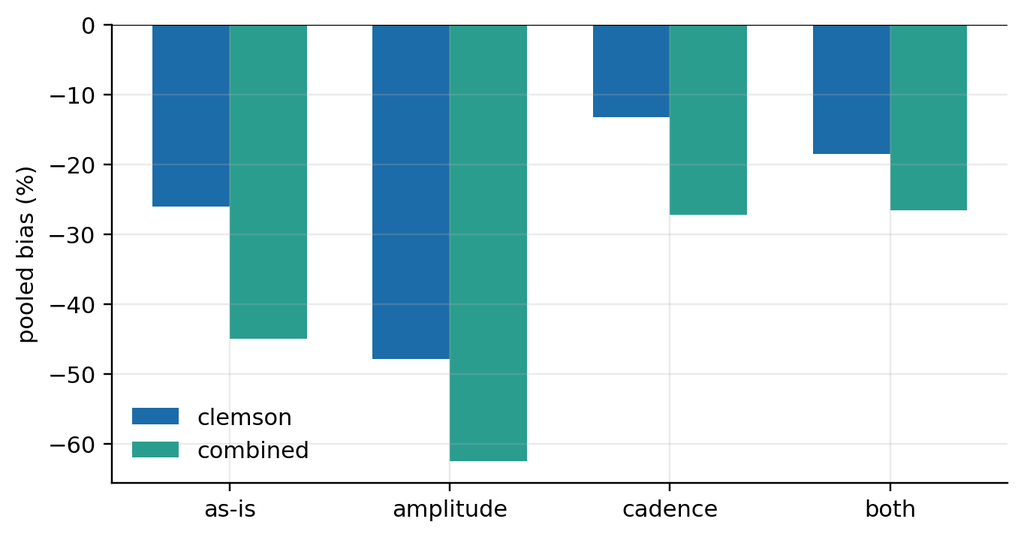

(b)

Figure 9

**Result.** On running, pooled bias is −26 % (`clemson`) and −45 % (`combined`) as-is.

- *Cadence only* (look 25 % slower) cuts the undercount to −13 % and −27 %: roughly half of the error goes away, so training-cadence coverage is a real contributor.
- *Amplitude only* (×0.2) makes it **worse** (−48 %, −62 %), and combining both is no better than cadence alone for `clemson` (−19 %) and about the same for `combined` (−27 %). The simple “running is clipped by the raster range” explanation is therefore not supported. Shrinking the signal also shrinks the waveform shape the model uses, so this manipulation is crude and does not rule out amplitude effects entirely.
- Even with cadence removed, an undercount of −13 % to −27 % remains, so other differences between running and walking waveforms also matter.
- Only `clemson` and `combined` were tested here, not `oxwalk`.

# 8. How our fit compares with the paper’s protocol

Checked against `scripts/`, `step_counting/*/code`, and the paper’s Appendix A (Table A1).

| Item | Paper | Our final fits | Verdict |
| --- | --- | --- | --- |
| Optimiser, LR, WD, batch, cosine to 1e-5, grad clip 1.0 | Adam 3e-4, 1e-4, 64, yes, 1.0 | identical (`_fit_common.py`) | ✅ same |
| Epochs | max 120 | 120 | ✅ same |
| Count loss: α_max, warmup, ramp | 0.15, 30, 50 | 0.15, 30 (ratio 0.25), 50 | ✅ same |
| Label width / rate / window | 5 @15 Hz, 7 @25 Hz, 60 s | same | ✅ same |
| Clemson input | gravity-removed raster, original labels | same | ✅ same |
| OxWalk input | unprocessed raster, motion-energy *realigned* training labels | same (realigned folder) | ✅ same |
| Raster ranges | per-axis 0.5/99.5 pct of training data | same (all participants) | ✅ same |
| Subject-balanced sampling | yes | yes | ✅ same |
| Combined (Clemson+OxWalk) model | not in paper | pooled at 15 Hz, label width 5 | ➕ our addition |
| **Training participants** | 21–35 train / validation / test splits | **all** participants, no hold-out | ⚠️ no in-fit generalisation estimate |
| **Checkpoint: Clemson** | `run_clemson.sh`: patience 999, `checkpoint_selection final` | final epoch | ✅ matches the repo’s actual protocol |
| **Checkpoint: OxWalk** | `train_one_fold`: best *validation* subject-relative MSE in the full-α phase, patience 8 | final epoch, no validation | ⚠️ differs |
| OxWalk warmup | `oxwalk/config.py` default `warmup_ratio 0.2` → 24 epochs (run script does not override) | 30 epochs | ⚠️ small difference vs the CV runs |
| Patience stated in paper | Table A1: 20 epochs | repo scripts: 8 (OxWalk), 999 (Clemson/cross-dataset) | ⚠️ paper text and code disagree |
| Model selection described in paper | “validation participants were used for model selection” | Clemson/cross-dataset code uses the final epoch | ⚠️ paper text and code disagree |

**Do the differences matter?**

- **Final-epoch weights vs validation-selected (OxWalk).** The late-epoch training loss is noisy, so final weights are a single draw from a flat, slightly noisy region. The effect on counts is probably a few percent either way, but it is a real departure from the OxWalk CV protocol and it cannot be quantified without a held-out run. Cheap remedy: average the weights of the last *k* epochs, or keep the epoch with the best *validation* count error from a held-out fit.
- **No held-out split.** Not a bug, but it means MAREA (and any other external set) is our only generalisation evidence. Training on all subjects is the right choice for a deployed model, as the paper’s own transfer experiments do.
- **Warmup 24 vs 30 (OxWalk CV).** Cosmetic; it shifts the α ramp by six epochs and the final weights still see α = 0.15.
- **Paper/code mismatch in patience and selection.** This is a *reproducibility-of-the-paper* issue, not a flaw in our fits. It is worth resolving with the authors because “validation participants for model selection” and “patience 20” are not what the released scripts do.
- **Count loss scale (Section 2).** The count term is unbounded and dominates the loss after epoch 32. That is the paper’s design, and the paper’s ablation (their Tables 7–9) shows it is needed, so our fit being faithful to it is correct. It does make train loss uninformative for convergence checking, so the per-term logging added in this repo (`bce`, `count_mse`, `alpha` in `loss_log.csv` for new runs) is worth keeping.

# 9. Does training on running fix it? Cross-validation with MAREA in the training pool

Everything above evaluates models that never saw MAREA. To test the obvious remedy we ran a **5-fold, participant-level cross-validation over all three cohorts** (`scripts/cv_with_marea.py`). Each fold holds out ~1/5 of Clemson (30 participants), OxWalk (39) and MAREA (19), keeping every recording of a participant on one side. Two arms use identical folds, seed and recipe (the `combined` recipe: 15 Hz, gravity-removed, label width 5, 120 epochs): **`no_marea`** trains on Clemson + OxWalk only; **`with_marea`** adds the MAREA training participants (all activities). Both are scored on the held-out participants of every cohort, so the contrast isolates what MAREA, including running, buys. Metric: per participant, steps summed over recordings, APE per participant, averaged (the Koffman convention); for MAREA, running and walking are scored separately.

```python
import glob
cvdir = CACHE / "cv_marea"
files = sorted(glob.glob(str(cvdir / "*.csv")))
if not files:
    print("CV results not found (analysis/cache/cv_marea); run scripts/cv_with_marea.py on the cluster.")
else:
    c = pd.concat([pd.read_csv(f) for f in files], ignore_index=True)
    c["subset"] = np.where(c.cohort != "marea", c.cohort, np.where(c.activity.str.contains("run"), "MAREA running", "MAREA walking"))
    pp = c.groupby(["arm", "subset", "subject"])[["true", "mass"]].sum().reset_index()
    pp["pe"] = (pp.mass - pp.true) / pp.true * 100; pp["ape"] = pp.pe.abs()
    def cvboot(g, n=2000):
        a, e = g.ape.to_numpy(), g.pe.to_numpy(); i = RNG.integers(0, len(g), (n, len(g)))
        return a.mean(), *np.percentile(a[i].mean(1), [2.5, 97.5]), e.mean()
    rows = []
    for sub in ["MAREA running", "MAREA walking", "clemson", "oxwalk"]:
        r = {"held-out subset": sub, "n participants": pp[(pp["subset"] == sub) & (pp.arm == "with_marea")].shape[0]}
        for arm in ["no_marea", "with_marea"]:
            m, lo, hi, mpe = cvboot(pp[(pp["subset"] == sub) & (pp.arm == arm)])
            r[f"{arm} MAPE"] = f"{m:.1f} [{lo:.1f}, {hi:.1f}]"; r[f"{arm} MPE"] = f"{mpe:+.1f}"
        rows.append(r)
    display(pd.DataFrame(rows))
```

Table 6: Held-out participants, 5-fold CV. MAPE % (participant-bootstrap 95% CI); MPE < 0 = undercount.

|  | held-out subset | n participants | no_marea MAPE | no_marea MPE | with_marea MAPE | with_marea MPE |
| --- | --- | --- | --- | --- | --- | --- |
| 0 | MAREA running | 19 | 52.0 [45.0, 59.2] | -52.0 | 3.1 [2.3, 3.9] | +1.2 |
| 1 | MAREA walking | 19 | 9.5 [6.0, 13.2] | -8.8 | 5.7 [2.9, 9.2] | -5.0 |
| 2 | clemson | 30 | 5.0 [3.5, 7.3] | -2.1 | 4.3 [3.1, 5.6] | -2.4 |
| 3 | oxwalk | 39 | 15.1 [9.3, 23.1] | +2.4 | 14.4 [8.4, 22.0] | +2.5 |

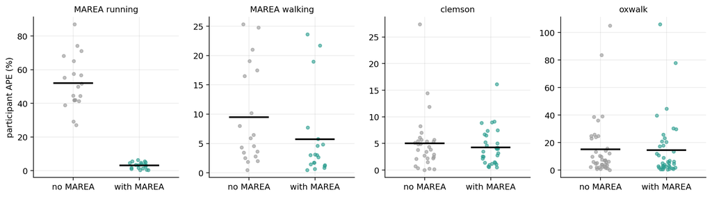

Figure 10: Per-participant absolute percentage error on held-out participants (each dot a participant; bar = mean).

```python
if files:
    fig, axs = plt.subplots(1, 4, figsize=(12, 3.4), sharey=False)
    for ax, sub in zip(axs, ["MAREA running", "MAREA walking", "clemson", "oxwalk"]):
        for i, arm in enumerate(["no_marea", "with_marea"]):
            v = pp[(pp["subset"] == sub) & (pp.arm == arm)].ape.to_numpy()
            ax.scatter(np.full(len(v), i) + RNG.uniform(-.15, .15, len(v)), v, s=14, alpha=.6,
                       color=["#999999", COL["combined"]][i])
            ax.hlines(v.mean(), i - .3, i + .3, color="k", lw=2)
        ax.set_xticks([0, 1]); ax.set_xticklabels(["no MAREA", "with MAREA"]); ax.set_title(sub, fontsize=10)
        ax.set_xlim(-.6, 1.6)
    axs[0].set_ylabel("participant APE (%)"); plt.tight_layout(); plt.show()
```

- **Running becomes countable once running is in training.** Held-out MAREA running goes from about a 52 % undercount (`no_marea`, as for the three models above) to ~3 % MAPE (MPE ≈ +1 %) with MAREA in training. Every one of the 19 held-out participants is within ~6 %, and indoor, outdoor and treadmill running are all 2–4 %. That is the cadence/amplitude coverage story of Section 4 confirmed by the direct remedy, not just by the Section 7 manipulations.
- **Walking improves too** (MAREA walking ~9.5 % → ~5.7 %), and Clemson (5.0 → 4.3 %) and OxWalk (15.1 → 14.4 %) do not get worse, so one model can serve all three regimes. Walking has a heavier tail than running: a few participants (marea_03, _10, _12) are 19–24 % low, and one fold averages 13 % on walking.
- **Limits.** All running comes from MAREA’s 19 people on three surfaces (135–177 steps/min), so the estimate is for similar participants, not for other running populations, devices or wrist placements. These CV models differ from the shipped `final_all3` (which sees every participant and has no held-out estimate of its own; expect its accuracy to be like the CV numbers). These numbers are **not** comparable to Section 6.2: Koffman’s algorithms were not trained on MAREA.

# 10. Conclusions

1. **The models are in line with the paper in the way that can be tested here.** On steady walking at an unseen sensor/protocol, error (~6–15 % MAPE, mild undercount) is within the paper’s zero-shot range, and the in-sample counts reproduce well.
2. **Running is a hard failure of the paper’s models, and is fixed by training on running data.** Training cadences do not cover running (a cadence-only manipulation recovers about half of the undercount); every paper-trained model undercounts severely, `oxwalk` worst. Do not use `clemson`/`oxwalk`/`combined` for running. Section 9 shows that adding MAREA to training brings held-out running to ~3 % MAPE without hurting walking, so use the three-cohort model (`all3`) when running matters, and validate it on running from a different population.
3. **No large fitting error was found.** Hyperparameters, losses, preprocessing and label setup match the paper. The notable departures are protocol-level (no validation-based checkpoint for OxWalk; all participants used for training) and the paper/code inconsistencies above.
4. **Recommended next steps.**
   - Re-fit with a held-out split for OxWalk to measure the final-epoch vs validation-selected gap.
   - Running data is the fix (Section 9). Next: validate `all3` on running from a different population/device, since all running here comes from 19 MAREA participants.
   - Versus the open-source tools: stepcount SSL matches our count accuracy on MAREA walking, recognises walking seconds better, and appears to cope with running better; closing that gap likely needs more diverse training data (SSL pretrains on UK Biobank), not more epochs.
   - Validate on a dataset closer to the paper’s hard case (free-living or irregular walking), e.g. PAAWS free-living walking labels or an activPAL-referenced wrist dataset.
   - Report MPE alongside MAPE, as the paper does, because the sign of the error differs by direction.

*Caveats.* MAREA’s step reference (foot-pressure heel strikes) is not the same instrument as the paper’s video annotation; 68 recordings from 19 participants give wide intervals; the counterfactual in Section 7 is a diagnostic and was run on two models.